# Cyclistic Capstone Project

Marwa Rabia

2023-11-27

## Introduction

This is my Capstone Project for my Google Data Analytics Course. This project is based on an imaginary company called Cyclistic and all data related to the company has been provided in the course itself.

## About the company

[figure not shown]

In 2016, Cyclistic launched a successful bike-share offering. Since then, the program has grown to a fleet of 5,824 bicycles that are geotracked and locked into a network of 692 stations across Chicago. The bikes can be unlocked from one station and returned to any other station in the system anytime.

Until now, Cyclistic’s marketing strategy relied on building general awareness and appealing to broad consumer segments. One approach that helped make these things possible was the flexibility of its pricing plans: single-ride passes, full-day passes, and annual memberships. Customers who purchase single-ride or full-day passes are referred to as casual riders. Customers who purchase annual memberships are Cyclistic members.

Cyclistic’s finance analysts have concluded that annual members are much more profitable than casual riders. Although the pricing flexibility helps Cyclistic attract more customers, Moreno believes that maximizing the number of annual members will be key to future growth. Rather than creating a marketing campaign that targets all-new customers, Moreno believes there is a very good chance to convert casual riders into members. She notes that casual riders are already aware of the Cyclistic program and have chosen Cyclistic for their mobility needs.

Moreno has set a clear goal: Design marketing strategies aimed at converting casual riders into annual members. In order to do that, however, the marketing analyst team needs to better understand how annual members and casual riders differ, why casual riders would buy a membership, and how digital media could affect their marketing tactics. Moreno and her team are interested in analyzing the Cyclistic historical bike trip data to identify trends.

## Characters and teams

- **Cyclistic:** A bike-share program that features more than 5,800 bicycles and 600 docking stations. Cyclistic sets itself apart by also offering reclining bikes, hand tricycles, and cargo bikes, making bike-share more inclusive to people with disabilities and riders who can’t use a standard two-wheeled bike. The majority of riders opt for traditional bikes; about 8% of riders use the assistive options. Cyclistic users are more likely to ride for leisure, but about 30% use them to commute to work each day.
- **Lily Moreno:** The director of marketing and your manager. Moreno is responsible for the development of campaigns and initiatives to promote the bike-share program. These may include email, social media, and other channels.
- **Cyclistic marketing analytics team:** A team of data analysts who are responsible for collecting, analyzing, and reporting data that helps guide Cyclistic marketing strategy. You joined this team six months ago and have been busy learning about Cyclistic’s mission and business goals — as well as how you, as a junior data analyst, can help Cyclistic achieve them.
- **Cyclistic executive team:** The notoriously detail-oriented executive team will decide whether to approve the recommended marketing program.

## Scenario

Cyclistic, a fictional bike-sharing company situated in Chicago, Illinois, enlisted me as a data analyst to contribute insights to the marketing team’s strategic initiatives. Within the customer base, Cyclistic caters to two primary segments: annual members and casual riders. The director of marketing recognizes the pivotal role of increasing annual memberships in ensuring the company’s future success.

Tasked with crafting a compelling strategy to convert casual riders into annual members, the marketing team seeks data-driven insights into the distinctive usage patterns of these two customer groups. Specifically, we aim to understand how casual riders and annual members differ in their utilization of Cyclistic bikes. In response to the director’s directive, the focus of the proposed strategy will be on leveraging digital media channels, such as email, social media, and other online platforms, to effectively communicate and encourage the transition from casual riding to annual memberships.

This Case Study will have 6 steps in total to find solutions to our required Business task. The 6 steps are: **Ask, Prepare, Process, Analyze, Share, Act.**

### Step 1 Ask (Business Questions)

The Goal of the Marketing director is to increase the number of annual memberships by converting more and more casual riders to increase profitability of the Company.

1. How do annual members and casual riders use Cyclistic bikes differently?
2. Why would casual riders buy Cyclistic annual memberships?
3. How can Cyclistic use digital media to influence casual riders to become members?

### Our Business Task:

1. How do annual members and casual riders use Cyclistic bikes differently?

### Step 2 : Preparing the Data

#### Information About The Data

- The company Cyclist is a fictional company; hence we are using data of a real world company to answer questions related to our business task.
- The following datasets were provided in the case study only Data link: Divvy trip data public dataset
- We have considered data for Months **January 2023 – June 2023.**

#### Licensing, Privacy, Reliability

- The data comes from a reliable source, without any bias as it is a real time data of a company which is from recent months.
- This data stands secure in an AWS portal and is an open dataset.
- The data has been made available by Motivate International Inc. under this license.

#### Tools Used

- I have used R Programming Language for the data cleaning and data processing phase.

#### Setting up my environment

```r
library(tidyverse)
```

```r
library(lubridate)
library(ggplot2)
library(janitor)
library(skimr)
library(dplyr)
```

#### Loading .csv files

```r
m1_2023 <- read.csv('Data\\202301-divvy-tripdata.csv')
m2_2023 <- read.csv('Data\\202302-divvy-tripdata.csv')
m3_2023 <- read.csv('Data\\202303-divvy-tripdata.csv')
m4_2023 <- read.csv('Data\\202304-divvy-tripdata.csv')
m5_2023 <- read.csv('Data\\202305-divvy-tripdata.csv')
m6_2023 <- read.csv('Data\\202306-divvy-tripdata.csv')
```

#### WRANGLE DATA AND COMBINE INTO A SINGLE FILE¶

Compare column names each of the files

```r
all(colnames(m1_2023) == colnames(m2_2023)&
    colnames(m1_2023) == colnames(m3_2023)&
    colnames(m1_2023) == colnames(m4_2023)&
    colnames(m1_2023) == colnames(m5_2023)&
    colnames(m1_2023) == colnames(m6_2023))
```

```
## [1] TRUE
```

Since the column are consistent we can go ahead with the combining

```r
all_data <- bind_rows(m1_2023,m2_2023,m3_2023,m4_2023,m5_2023,m6_2023)
```

Save All data as CSV

```r
write.csv(all_data, file = "Data_before_cleaning.csv", row.names = FALSE)
```

#### Understanding The Data

```r
head(all_data) # Checking the first few rows of the dataset
```

```
##            ride_id rideable_type          started_at            ended_at
## 1 F96D5A74A3E41399 electric_bike 2023-01-21 20:05:42 2023-01-21 20:16:33
## 2 13CB7EB698CEDB88  classic_bike 2023-01-10 15:37:36 2023-01-10 15:46:05
## 3 BD88A2E670661CE5 electric_bike 2023-01-02 07:51:57 2023-01-02 08:05:11
## 4 C90792D034FED968  classic_bike 2023-01-22 10:52:58 2023-01-22 11:01:44
## 5 3397017529188E8A  classic_bike 2023-01-12 13:58:01 2023-01-12 14:13:20
## 6 58E68156DAE3E311 electric_bike 2023-01-31 07:18:03 2023-01-31 07:21:16
##              start_station_name start_station_id               end_station_name
## 1   Lincoln Ave & Fullerton Ave     TA1309000058      Hampden Ct & Diversey Ave
## 2         Kimbark Ave & 53rd St     TA1309000037        Greenwood Ave & 47th St
## 3        Western Ave & Lunt Ave           RP-005 Valli Produce - Evanston Plaza
## 4         Kimbark Ave & 53rd St     TA1309000037        Greenwood Ave & 47th St
## 5         Kimbark Ave & 53rd St     TA1309000037        Greenwood Ave & 47th St
## 6 Lakeview Ave & Fullerton Pkwy     TA1309000019      Hampden Ct & Diversey Ave
##   end_station_id start_lat start_lng  end_lat   end_lng member_casual
## 1       202480.0  41.92407 -87.64628 41.93000 -87.64000        member
## 2   TA1308000002  41.79957 -87.59475 41.80983 -87.59938        member
## 3            599  42.00857 -87.69048 42.03974 -87.69941        casual
## 4   TA1308000002  41.79957 -87.59475 41.80983 -87.59938        member
## 5   TA1308000002  41.79957 -87.59475 41.80983 -87.59938        member
## 6       202480.0  41.92607 -87.63886 41.93000 -87.64000        member
```

```r
summary(all_data) # To Understand statistics about the Data set
```

```
##    ride_id          rideable_type       started_at          ended_at
##  Length:2390459     Length:2390459     Length:2390459     Length:2390459
##  Class :character   Class :character   Class :character   Class :character
##  Mode  :character   Mode  :character   Mode  :character   Mode  :character
##
##
##
##
##  start_station_name start_station_id   end_station_name   end_station_id
##  Length:2390459     Length:2390459     Length:2390459     Length:2390459
##  Class :character   Class :character   Class :character   Class :character
##  Mode  :character   Mode  :character   Mode  :character   Mode  :character
##
##
##
##
##    start_lat       start_lng         end_lat         end_lng
##  Min.   :41.64   Min.   :-87.87   Min.   : 0.00   Min.   :-88.16
##  1st Qu.:41.88   1st Qu.:-87.66   1st Qu.:41.88   1st Qu.:-87.66
##  Median :41.90   Median :-87.64   Median :41.90   Median :-87.64
##  Mean   :41.90   Mean   :-87.65   Mean   :41.90   Mean   :-87.65
##  3rd Qu.:41.93   3rd Qu.:-87.63   3rd Qu.:41.93   3rd Qu.:-87.63
##  Max.   :42.07   Max.   :-87.52   Max.   :42.11   Max.   :  0.00
##                                   NA's   :2460    NA's   :2460
##  member_casual
##  Length:2390459
##  Class :character
##  Mode  :character
##
##
##
##
```

```r
colnames(all_data) #Column names of the Data set
```

```
##  [1] "ride_id"            "rideable_type"      "started_at"
##  [4] "ended_at"           "start_station_name" "start_station_id"
##  [7] "end_station_name"   "end_station_id"     "start_lat"
## [10] "start_lng"          "end_lat"            "end_lng"
## [13] "member_casual"
```

```r
skim_without_charts(all_data)   # 2387999
```

Data summary

| Name | all_data |
| --- | --- |
| Number of rows | 2390459 |
| Number of columns | 13 |
| _______________________ |  |
| Column type frequency: |  |
| character | 9 |
| numeric | 4 |
| ________________________ |  |
| Group variables | None |

**Variable type: character**

| skim_variable | n_missing | complete_rate | min | max | empty | n_unique | whitespace |
| --- | --- | --- | --- | --- | --- | --- | --- |
| ride_id | 0 | 1 | 16 | 16 | 0 | 2390459 | 0 |
| rideable_type | 0 | 1 | 11 | 13 | 0 | 3 | 0 |
| started_at | 0 | 1 | 19 | 19 | 0 | 2049649 | 0 |
| ended_at | 0 | 1 | 19 | 19 | 0 | 2055268 | 0 |
| start_station_name | 0 | 1 | 0 | 64 | 357417 | 1461 | 0 |
| start_station_id | 0 | 1 | 0 | 35 | 357549 | 1388 | 0 |
| end_station_name | 0 | 1 | 0 | 64 | 380963 | 1467 | 0 |
| end_station_id | 0 | 1 | 0 | 35 | 381104 | 1392 | 0 |
| member_casual | 0 | 1 | 6 | 6 | 0 | 2 | 0 |

**Variable type: numeric**

| skim_variable | n_missing | complete_rate | mean | sd | p0 | p25 | p50 | p75 | p100 |
| --- | --- | --- | --- | --- | --- | --- | --- | --- | --- |
| start_lat | 0 | 1 | 41.90 | 0.05 | 41.64 | 41.88 | 41.90 | 41.93 | 42.07 |
| start_lng | 0 | 1 | -87.65 | 0.03 | -87.87 | -87.66 | -87.64 | -87.63 | -87.52 |
| end_lat | 2460 | 1 | 41.90 | 0.06 | 0.00 | 41.88 | 41.90 | 41.93 | 42.11 |
| end_lng | 2460 | 1 | -87.65 | 0.08 | -88.16 | -87.66 | -87.64 | -87.63 | 0.00 |

```r
glimpse(all_data) #Summary of the Data set and Data Types of Columns
```

```
## Rows: 2,390,459
## Columns: 13
## $ ride_id            <chr> "F96D5A74A3E41399", "13CB7EB698CEDB88", "BD88A2E670…
## $ rideable_type      <chr> "electric_bike", "classic_bike", "electric_bike", "…
## $ started_at         <chr> "2023-01-21 20:05:42", "2023-01-10 15:37:36", "2023…
## $ ended_at           <chr> "2023-01-21 20:16:33", "2023-01-10 15:46:05", "2023…
## $ start_station_name <chr> "Lincoln Ave & Fullerton Ave", "Kimbark Ave & 53rd …
## $ start_station_id   <chr> "TA1309000058", "TA1309000037", "RP-005", "TA130900…
## $ end_station_name   <chr> "Hampden Ct & Diversey Ave", "Greenwood Ave & 47th …
## $ end_station_id     <chr> "202480.0", "TA1308000002", "599", "TA1308000002", …
## $ start_lat          <dbl> 41.92407, 41.79957, 42.00857, 41.79957, 41.79957, 4…
## $ start_lng          <dbl> -87.64628, -87.59475, -87.69048, -87.59475, -87.594…
## $ end_lat            <dbl> 41.93000, 41.80983, 42.03974, 41.80983, 41.80983, 4…
## $ end_lng            <dbl> -87.64000, -87.59938, -87.69941, -87.59938, -87.599…
## $ member_casual      <chr> "member", "member", "casual", "member", "member", "…
```

#### Observations about the Data set

- Total number of rows = 2,390,459 and columns = 13.
- Each row represents a unique entry and there are no duplicate values.
- There are 2 unique types of Customers and 3 unique types of bikes.

#### Problems Noted

- Columns having missing values : start_station_name, start_station_id, end_station_name, end_station_id, end_lat, end_lng.
- Some Columns have to be renamed as they are not intuitive.
- The data can only be aggregated at the ride-level. We will want to add some additional columns of data – such as day, month, year – that provide additional opportunities to aggregate the data.
- We will add a column ride length to understand the amount of time that has been spent by a user in a particular ride.

### Step 3 Processing the Data

#### Renaming Column

```r
all_data <- rename(all_data, "user_type" = "member_casual")
```

#### Convert started_at and ended_at to dttm

```r
all_data<-mutate(all_data,started_at=ymd_hms(started_at),
                          ended_at =ymd_hms(ended_at))
```

#### Adding Columns

```r
all_data$ride_length<-difftime(all_data$ended_at,all_data$started_at)
all_data$date <- as.Date(all_data$started_at) #The default format is yyyy-mm-dd
all_data$month <- format(as.Date(all_data$date), "%b")
all_data$day <- format(as.Date(all_data$date), "%d")
all_data$year <- format(as.Date(all_data$date), "%Y")
all_data$day_of_week <- format(as.Date(all_data$date), "%A")
```

```r
all_data$date <- as.numeric(all_data$ride_length)
```

### Clean Data

#### remove duplicate rows

```r
all_data <- distinct(all_data)
```

#### remove rows with null values

```r
all_data <- na.omit(all_data)
```

- Negative ride_length values and outliers
- ride_length values that are negative are not correct as the difference between end time and start time has to be a positive value.
- If the ride_length values are less than 60 seconds or more than 86,400 seconds (24 hours), then they will be considered outliers as mentioned in the Website.

```r
all_clean_data <- filter(all_data, !(ride_length<60), !(ride_length>86400))
```

```r
min(all_clean_data$ride_length)
```

```
## Time difference of 60 secs
```

```r
max(all_clean_data$ride_length)
```

```
## Time difference of 86146 secs
```

#### Checking the changes that we made to our Data

```r
skim_without_charts(all_clean_data)
```

Data summary

| Name | all_clean_data |
| --- | --- |
| Number of rows | 2315029 |
| Number of columns | 19 |
| _______________________ |  |
| Column type frequency: |  |
| character | 11 |
| difftime | 1 |
| numeric | 5 |
| POSIXct | 2 |
| ________________________ |  |
| Group variables | None |

**Variable type: character**

| skim_variable | n_missing | complete_rate | min | max | empty | n_unique | whitespace |
| --- | --- | --- | --- | --- | --- | --- | --- |
| ride_id | 0 | 1 | 16 | 16 | 0 | 2315029 | 0 |
| rideable_type | 0 | 1 | 11 | 13 | 0 | 3 | 0 |
| start_station_name | 0 | 1 | 0 | 64 | 336188 | 1454 | 0 |
| start_station_id | 0 | 1 | 0 | 35 | 336313 | 1381 | 0 |
| end_station_name | 0 | 1 | 0 | 64 | 350091 | 1454 | 0 |
| end_station_id | 0 | 1 | 0 | 35 | 350229 | 1381 | 0 |
| user_type | 0 | 1 | 6 | 6 | 0 | 2 | 0 |
| month | 0 | 1 | 3 | 3 | 0 | 6 | 0 |
| day | 0 | 1 | 2 | 2 | 0 | 31 | 0 |
| year | 0 | 1 | 4 | 4 | 0 | 1 | 0 |
| day_of_week | 0 | 1 | 6 | 9 | 0 | 7 | 0 |

**Variable type: difftime**

| skim_variable | n_missing | complete_rate | min | max | median | n_unique |
| --- | --- | --- | --- | --- | --- | --- |
| ride_length | 0 | 1 | 60 secs | 86146 secs | 569 secs | 15042 |

**Variable type: numeric**

| skim_variable | n_missing | complete_rate | mean | sd | p0 | p25 | p50 | p75 | p100 |
| --- | --- | --- | --- | --- | --- | --- | --- | --- | --- |
| start_lat | 0 | 1 | 41.90 | 0.05 | 41.64 | 41.88 | 41.90 | 41.93 | 42.07 |
| start_lng | 0 | 1 | -87.65 | 0.03 | -87.87 | -87.66 | -87.64 | -87.63 | -87.52 |
| end_lat | 0 | 1 | 41.90 | 0.05 | 0.00 | 41.88 | 41.90 | 41.93 | 42.11 |
| end_lng | 0 | 1 | -87.65 | 0.06 | -88.16 | -87.66 | -87.64 | -87.63 | 0.00 |
| date | 0 | 1 | 906.51 | 1825.66 | 60.00 | 331.00 | 569.00 | 1008.00 | 86146.00 |

**Variable type: POSIXct**

| skim_variable | n_missing | complete_rate | min | max | median | n_unique |
| --- | --- | --- | --- | --- | --- | --- |
| started_at | 0 | 1 | 2023-01-01 00:02:06 | 2023-06-30 23:59:56 | 2023-05-09 01:49:51 | 1993158 |
| ended_at | 0 | 1 | 2023-01-01 00:07:23 | 2023-07-01 18:26:01 | 2023-05-09 02:23:25 | 1998671 |

```r
colnames(all_clean_data)
```

```
##  [1] "ride_id"            "rideable_type"      "started_at"
##  [4] "ended_at"           "start_station_name" "start_station_id"
##  [7] "end_station_name"   "end_station_id"     "start_lat"
## [10] "start_lng"          "end_lat"            "end_lng"
## [13] "user_type"          "ride_length"        "date"
## [16] "month"              "day"                "year"
## [19] "day_of_week"
```

```r
summary(all_clean_data)
```

```
##    ride_id          rideable_type        started_at
##  Length:2315029     Length:2315029     Min.   :2023-01-01 00:02:06.00
##  Class :character   Class :character   1st Qu.:2023-03-28 08:21:52.00
##  Mode  :character   Mode  :character   Median :2023-05-09 01:49:51.00
##                                        Mean   :2023-04-27 07:36:30.43
##                                        3rd Qu.:2023-06-05 17:02:55.00
##                                        Max.   :2023-06-30 23:59:56.00
##     ended_at                      start_station_name start_station_id
##  Min.   :2023-01-01 00:07:23.00   Length:2315029     Length:2315029
##  1st Qu.:2023-03-28 08:32:38.00   Class :character   Class :character
##  Median :2023-05-09 02:23:25.00   Mode  :character   Mode  :character
##  Mean   :2023-04-27 07:51:36.94
##  3rd Qu.:2023-06-05 17:18:30.00
##  Max.   :2023-07-01 18:26:01.00
##  end_station_name   end_station_id       start_lat       start_lng
##  Length:2315029     Length:2315029     Min.   :41.64   Min.   :-87.87
##  Class :character   Class :character   1st Qu.:41.88   1st Qu.:-87.66
##  Mode  :character   Mode  :character   Median :41.90   Median :-87.64
##                                        Mean   :41.90   Mean   :-87.65
##                                        3rd Qu.:41.93   3rd Qu.:-87.63
##                                        Max.   :42.07   Max.   :-87.52
##     end_lat         end_lng        user_type         ride_length
##  Min.   : 0.00   Min.   :-88.16   Length:2315029     Length:2315029
##  1st Qu.:41.88   1st Qu.:-87.66   Class :character   Class :difftime
##  Median :41.90   Median :-87.64   Mode  :character   Mode  :numeric
##  Mean   :41.90   Mean   :-87.65
##  3rd Qu.:41.93   3rd Qu.:-87.63
##  Max.   :42.11   Max.   :  0.00
##       date            month               day                year
##  Min.   :   60.0   Length:2315029     Length:2315029     Length:2315029
##  1st Qu.:  331.0   Class :character   Class :character   Class :character
##  Median :  569.0   Mode  :character   Mode  :character   Mode  :character
##  Mean   :  906.5
##  3rd Qu.: 1008.0
##  Max.   :86146.0
##  day_of_week
##  Length:2315029
##  Class :character
##  Mode  :character
##
##
##
```

```r
sample_n(all_clean_data,50)
```

```
##             ride_id rideable_type          started_at            ended_at
## 1  01E41A6DB55CEBA2  classic_bike 2023-04-27 20:49:26 2023-04-27 20:53:11
## 2  DE7CB1FFA56897CD electric_bike 2023-06-04 14:38:21 2023-06-04 14:46:49
## 3  75FAC1AE935412B3 electric_bike 2023-03-06 21:26:36 2023-03-06 21:33:23
## 4  65C54A3EA073186C  classic_bike 2023-05-24 06:46:31 2023-05-24 06:59:42
## 5  1530C9538003120A  classic_bike 2023-04-05 17:50:26 2023-04-05 17:53:53
## 6  C34DE632C08E19F6 electric_bike 2023-04-19 17:22:28 2023-04-19 17:35:22
## 7  F33EC185BCA8A2F7  classic_bike 2023-02-06 21:56:00 2023-02-06 21:58:30
## 8  34F245E602CEDA9E electric_bike 2023-02-19 18:10:04 2023-02-19 18:55:25
## 9  FA0682417321F4DF electric_bike 2023-05-08 23:14:49 2023-05-08 23:18:31
## 10 0955E13F66E53D7E electric_bike 2023-06-22 08:02:43 2023-06-22 08:14:53
## 11 2806A72127E55D16 electric_bike 2023-03-24 16:54:03 2023-03-24 16:59:24
## 12 75ADB276AD5CC2FF  classic_bike 2023-05-24 06:35:03 2023-05-24 06:36:47
## 13 F14EC65532DAE6B6  classic_bike 2023-06-27 06:25:38 2023-06-27 10:36:40
## 14 AF062678ECF716DC electric_bike 2023-03-08 09:07:22 2023-03-08 09:12:48
```

[output cut: 189 more lines]

Save data after cleaning

```r
write.csv(all_clean_data, file = "Data_after_cleaning.csv", row.names = FALSE)
```

### Step 4 : Analyzing and Visualising the Data

- Descriptive Analysis

```r
summary(all_clean_data$ride_length)
```

```
##   Length    Class     Mode
##  2315029 difftime  numeric
```

#### Data for Average ride_length by user_type

```r
all_clean_data%>%
  group_by(user_type) %>%
  summarise(average_ride_length = mean(ride_length))
```

```
## # A tibble: 2 × 2
##   user_type average_ride_length
##   <chr>     <drtn>
## 1 casual    1250.6332 secs
## 2 member     724.2051 secs
```

- Average Ride Length
  - **Member** 12.04 minutes
  - **Casual** 20.84 minutes

#### Visualizing Average ride_length

```
## Defaulting to continuous.
```

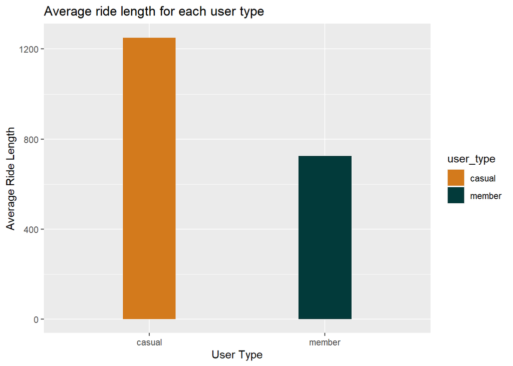

```r
all_clean_data %>%
  group_by(user_type) %>%
  summarise(average_ride_length = mean(ride_length)) %>%
  ggplot() + geom_bar(mapping = aes(x = user_type, y = average_ride_length, fill = user_type), stat = 'identity', width = 0.3) + labs(title = "Average ride length for each user type", x = "User Type", y = "Average Ride Length") + scale_fill_manual(values = c("#d37a1c", "#023a3a"))
```

#### Key Insights * Average ride_length or ride time of casual rides is 1250.63 secs(~21 mins.) while that of member rides is 724.2051 secs (12 mins.)

#### Total Number of Rides by User Type and Type of the bike

```r
all_clean_data %>%
  group_by(user_type, rideable_type) %>%
  summarise(number_of_rides = n())
```

```
## # A tibble: 5 × 3
## # Groups:   user_type [2]
##   user_type rideable_type number_of_rides
##   <chr>     <chr>                   <int>
## 1 casual    classic_bike           301333
## 2 casual    docked_bike             42377
## 3 casual    electric_bike          457993
## 4 member    classic_bike           721162
## 5 member    electric_bike          792164
```

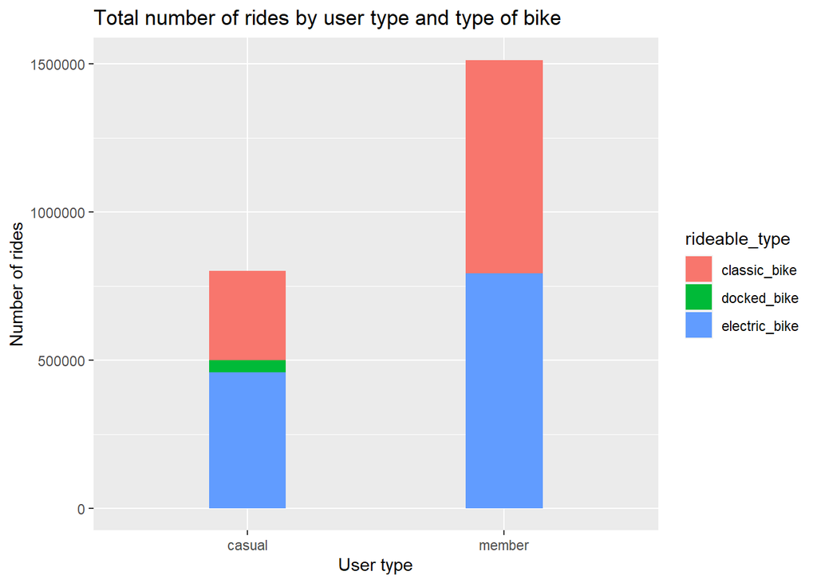

```r
all_clean_data %>%
  group_by(user_type, rideable_type) %>%
  summarise(number_of_rides = n()) %>%
  ggplot() + geom_bar(mapping = aes(x=user_type, y=number_of_rides, fill=rideable_type), stat='identity', width = 0.3) + labs(title = "Total number of rides by user type and type of bike", x="User type", y="Number of rides")
```

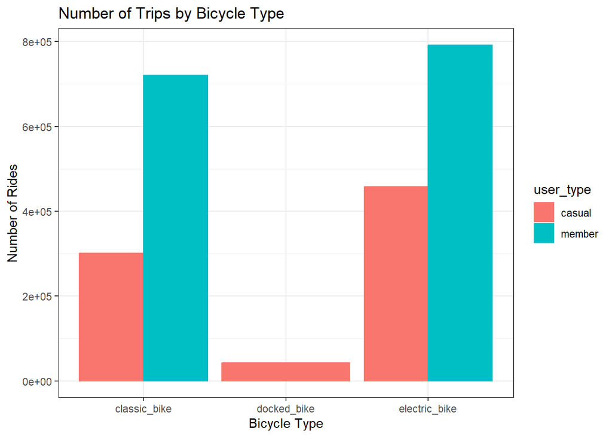

```r
all_clean_data %>%
  group_by(rideable_type,user_type) %>%
  dplyr::summarize(count_trips = n()) %>%
  ggplot(aes(x=rideable_type, y=count_trips, fill=user_type, color=user_type)) +
  geom_bar(stat='identity', position='dodge') +
  theme_bw()+
  labs(title="Number of Trips by Bicycle Type", x="Bicycle Type", y="Number of Rides")
```

Key Insights * Docked bike is not used by anyone who is a member and is not that popular as an option among casual riders as well. * Classic and electric bike are a popular choice among casual as well as member riders.

#### Total number of riders for each user type by months

```r
all_clean_data %>%
  group_by(user_type, month) %>%
  summarise(number_of_rides = n()) %>%
  arrange(user_type)
```

```
## # A tibble: 12 × 3
## # Groups:   user_type [2]
##    user_type month number_of_rides
##    <chr>     <chr>           <int>
##  1 casual    Apr            142121
##  2 casual    Feb             41723
##  3 casual    Jan             38731
##  4 casual    Jun            292232
##  5 casual    Mar             60125
##  6 casual    May            226771
##  7 member    Apr            269042
##  8 member    Feb            142601
##  9 member    Jan            145246
## 10 member    Jun            407688
## 11 member    Mar            189289
## 12 member    May            359460
```

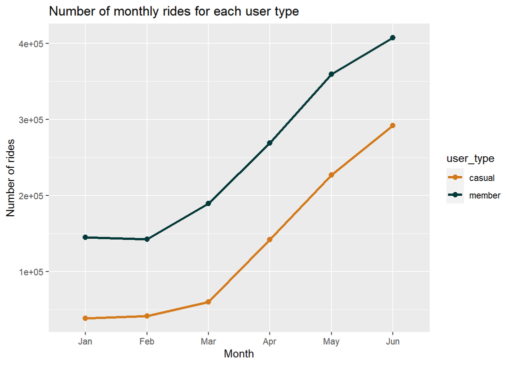

```r
all_clean_data <- all_clean_data %>%
  mutate(month =factor(month, levels = c( "Jan", "Feb", "Mar","Apr", "May", "Jun")))
all_clean_data %>%
  group_by(user_type, month) %>%
  summarise(number_of_rides = n()) %>%
  ggplot(aes(x=month, y=number_of_rides, group=user_type, color=user_type)) + geom_line(size=1.1) + geom_point(size=2.2)+ labs(title = "Number of monthly rides for each user type", x="Month", y="Number of rides") + scale_color_manual(values = c("#d37a1c", "#023a3a"))
```

#### Total number of riders for each user type by Days

```r
all_clean_data %>%
  group_by(user_type, day_of_week) %>%
  summarise(number_of_rides = n()) %>%
  arrange(user_type)
```

```
## # A tibble: 14 × 3
## # Groups:   user_type [2]
##    user_type day_of_week number_of_rides
##    <chr>     <chr>                 <int>
##  1 casual    Friday               125553
##  2 casual    Monday                90337
##  3 casual    Saturday             157465
##  4 casual    Sunday               122190
##  5 casual    Thursday             110043
##  6 casual    Tuesday               94076
##  7 casual    Wednesday            102039
##  8 member    Friday               223626
##  9 member    Monday               201811
## 10 member    Saturday             188011
## 11 member    Sunday               161558
## 12 member    Thursday             246649
## 13 member    Tuesday              242030
## 14 member    Wednesday            249641
```

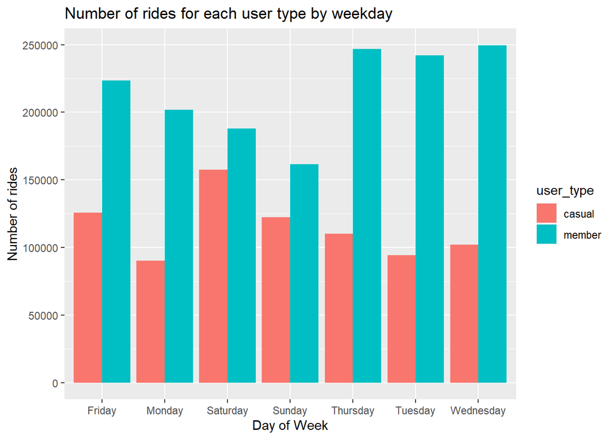

```r
all_clean_data %>%
  group_by(user_type, day_of_week) %>%
  summarise(number_of_rides = n()) %>%
  ggplot() + geom_col(mapping = aes(x=day_of_week, y=number_of_rides, fill=user_type), position = "dodge") +
  labs(title = "Number of rides for each user type by weekday", x="Day of Week", y="Number of rides")
```

#### Find popular start station for member riders

```r
all_clean_data %>%
  group_by(user_type,start_station_name) %>%
  dplyr::summarise(number_of_rides = n()) %>%
  filter(start_station_name != "", "member" == user_type) %>%
  arrange(-number_of_rides) %>%
  head(n=5)
```

```
## # A tibble: 5 × 3
## # Groups:   user_type [1]
##   user_type start_station_name           number_of_rides
##   <chr>     <chr>                                  <int>
## 1 member    Kingsbury St & Kinzie St               11335
## 2 member    Clinton St & Washington Blvd           11004
## 3 member    Clark St & Elm St                      10492
## 4 member    University Ave & 57th St               10268
## 5 member    Ellis Ave & 60th St                     9595
```

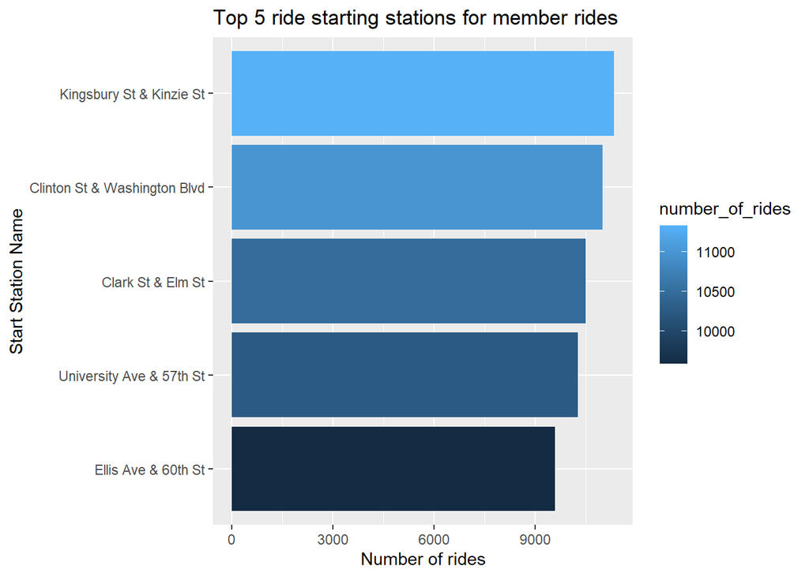

```r
#Find popular start station for member riders
all_clean_data %>%
  group_by(user_type,start_station_name) %>%
  dplyr::summarise(number_of_rides = n()) %>%
  filter(start_station_name != "", "member" == user_type) %>%
  arrange(-number_of_rides) %>%
  head(n=5)  %>%
  mutate(start_station_name= fct_reorder(start_station_name, number_of_rides)) %>%
  ggplot() + geom_bar(mapping = aes(x=start_station_name, y=number_of_rides, fill=number_of_rides), stat = 'identity') + coord_flip() + labs(title = "Top 5 ride starting stations for member rides", x="Start Station Name", y="Number of rides")
```

#### Find popular start station for casual riders

```r
all_clean_data %>%
  group_by(user_type,start_station_name) %>%
  dplyr::summarise(number_of_rides = n()) %>%
  filter(start_station_name != "", "casual" == user_type) %>%
  arrange(-number_of_rides) %>%
  head(n=5)
```

```
## # A tibble: 5 × 3
## # Groups:   user_type [1]
##   user_type start_station_name                 number_of_rides
##   <chr>     <chr>                                        <int>
## 1 casual    Streeter Dr & Grand Ave                      17458
## 2 casual    DuSable Lake Shore Dr & Monroe St            11772
## 3 casual    Michigan Ave & Oak St                         8479
## 4 casual    Millennium Park                               7963
## 5 casual    DuSable Lake Shore Dr & North Blvd            7618
```

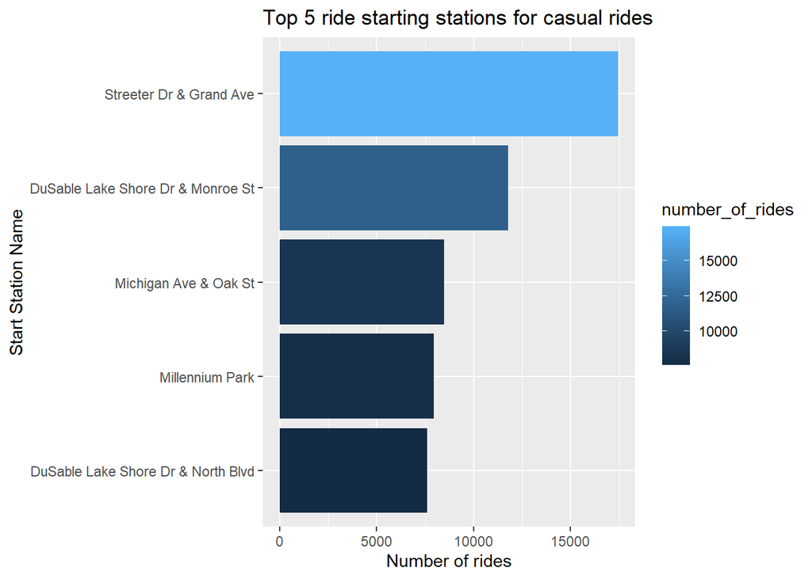

```r
all_clean_data %>%
  group_by(user_type,start_station_name) %>%
  dplyr::summarise(number_of_rides = n()) %>%
  filter(start_station_name != "", "casual" == user_type) %>%
  arrange(-number_of_rides) %>%
  head(n=5)  %>%
  mutate(start_station_name= fct_reorder(start_station_name, number_of_rides)) %>%
  ggplot() + geom_bar(mapping = aes(x=start_station_name, y=number_of_rides, fill=number_of_rides), stat = 'identity') + coord_flip() + labs(title = "Top 5 ride starting stations for casual rides", x="Start Station Name", y="Number of rides")
```

#### Find popular end station for member riders

```r
all_clean_data %>%
  group_by(user_type,end_station_name) %>%
  dplyr::summarise(number_of_rides = n()) %>%
  filter(end_station_name != "", "member" == user_type) %>%
  arrange(-number_of_rides) %>%
  head(n=5)
```

```
## # A tibble: 5 × 3
## # Groups:   user_type [1]
##   user_type end_station_name             number_of_rides
##   <chr>     <chr>                                  <int>
## 1 member    Clinton St & Washington Blvd           11722
## 2 member    Kingsbury St & Kinzie St               11449
## 3 member    University Ave & 57th St               10409
## 4 member    Clark St & Elm St                      10380
## 5 member    Wells St & Concord Ln                   9647
```

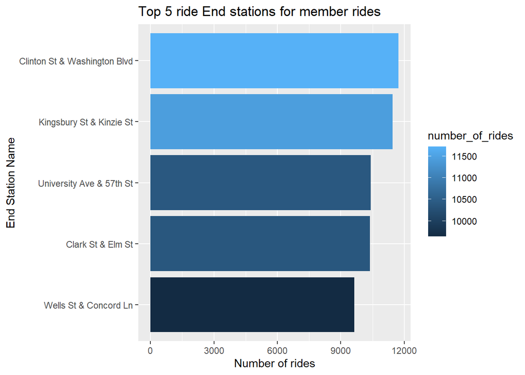

```r
all_clean_data %>%
  group_by(user_type,end_station_name) %>%
  dplyr::summarise(number_of_rides = n()) %>%
  filter(end_station_name != "", "member" == user_type) %>%
  arrange(-number_of_rides) %>%
  head(n=5)  %>%
  mutate(end_station_name= fct_reorder(end_station_name, number_of_rides)) %>%
  ggplot() + geom_bar(mapping = aes(x=end_station_name, y=number_of_rides, fill=number_of_rides), stat = 'identity') + coord_flip() + labs(title = "Top 5 ride End stations for member rides", x="End Station Name", y="Number of rides")
```

```r
all_clean_data %>%
  group_by(user_type,end_station_name) %>%
  dplyr::summarise(number_of_rides = n()) %>%
  filter(end_station_name != "", "casual" == user_type) %>%
  arrange(-number_of_rides) %>%
  head(n=5)
```

```
## # A tibble: 5 × 3
## # Groups:   user_type [1]
##   user_type end_station_name                   number_of_rides
##   <chr>     <chr>                                        <int>
## 1 casual    Streeter Dr & Grand Ave                      18974
## 2 casual    DuSable Lake Shore Dr & Monroe St            10613
## 3 casual    Michigan Ave & Oak St                         8996
## 4 casual    Millennium Park                               8797
## 5 casual    DuSable Lake Shore Dr & North Blvd            8744
```

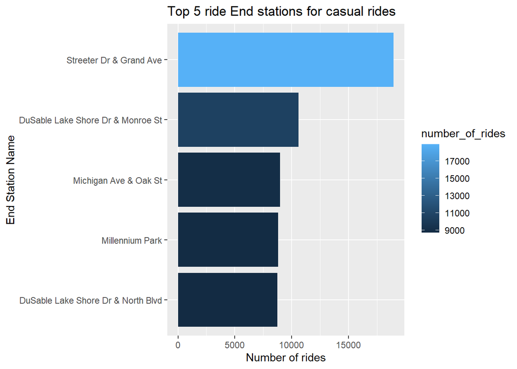

```r
all_clean_data %>%
  group_by(user_type,end_station_name) %>%
  dplyr::summarise(number_of_rides = n()) %>%
  filter(end_station_name != "", "casual" == user_type) %>%
  arrange(-number_of_rides) %>%
  head(n=5)  %>%
  mutate(end_station_name= fct_reorder(end_station_name, number_of_rides)) %>%
  ggplot() + geom_bar(mapping = aes(x=end_station_name, y=number_of_rides, fill=number_of_rides), stat = 'identity') + coord_flip() + labs(title = "Top 5 ride End stations for casual rides", x="End Station Name", y="Number of rides")
```

### EXPORT SUMMARY FILE FOR FURTHER ANALYSIS

```r
write.csv(all_clean_data, file = "yearly_trips_report.csv")
```

### Step 6 : Act

#### Conclusions from the analysis

- 1-The average ride length for casual rides is 20 minutes which is more than member rides - 12 minutes.
- 2-Analysis based on Months :
  - For Casual riders the highest number of rides are in the months of May and Jun. The months with the lowest number of rides are January and February.
  - For Member riders the highest number of rides are in the months of May and Jun. The months with the lowest number of rides are January and February.
- 3-Analysis based on Days :
  - Member rides are highest on Thursday, Tuesday and Wednesday.
  - Casual rides are lowest on Monday and Tuesday.
- 4-Analysis based on Location :
  - The top 5 ride starting stations for Member users are- Kingsbury St & Kinzie St,Clinton St & Washington Blvd, Clark St & Elm St, University Ave & 57th St, Ellis Ave & 60th St.
  - The top 5 ride starting stations for Casual users are- Streeter Dr & Grand Ave,DuSable Lake Shore Dr & Monroe St,Michigan Ave & Oak St,Millennium Park, DuSable Lake Shore Dr & North Blvd.
  - The top 5 ride Ending stations for Member users are-Clinton St & Washington Blvd,Kingsbury St & Kinzie St, University Ave & 57th St, Clark St & Elm St, Wells St & Concord Ln.
  - The top 5 ride Ending stations for Casual users are- Streeter Dr & Grand Ave, DuSable Lake Shore Dr & Monroe St, Michigan Ave & Oak St, Millennium Park, DuSable Lake Shore Dr & North Blvd

#### Conclusions

- Casual riders take less trips/rides but for longer durations of time vs members

### Recommendations¶

#### Members and casual riders differ in how long they use the bikes and how often they use the bikes. In order to get more casual riders to buy a membership my top recommendations are:

- Give discounts for longer rides when you have a membership
- Longer rides can get some type of rewards program when they become members